# **Lab 6:** Building a spam filter

## Announcements

- Fill out the surveys from the email I sent.
- **Important note:** you should remove `drop_na()` from Lab 5 if you used that function anywhere. Use `na.rm = TRUE` instead!

## Lab 6 Intro

*Make sure to load your packages first*

```r
library(tidyverse)    #umbrella suite of packages
library(openintro)    #data is from this package
library(janitor)      #for making tables
library(ggridges)     #for density ridge plots
```

## Lab 6 Exercises

### Exercise 1

**Exercise 1.** Create and add a new variable called `Spam` to the `email` dataframe which takes the value “yes” when the value for `spam` is 1, and “no” otherwise. Then print the frequency distribution of the variable `Spam` you have just created.

**Hint:** I have provided partial code for you below. You will need to create a code chunk in your lab report containing this code with the blanks filled in.

Use the example code provided by the professor to do this one.

Note that the syntax for the `ifelse()` function is `ifelse(test, yes, no)`.

- `test` represents the condition to evaluate
- `yes` is the value the variable should take if `test` returns `TRUE`
- `no` is the value the variable should take if `test` returns `FALSE`

```r
email <- email %>%
             mutate(Spam = ifelse(spam == 1, "yes", "no" ))
```

**Make sure to verify whether your variable was created as desired based on the value you put for `test` in the `ifelse()` function.**

### Exercise 2

**Exercise 2.** Construct a density ridge plot to examine the distribution of `num_char` by whether or not an email is classified as `Spam.` Then calculate the median number of characters for spam and non-spam messages. Be sure to show your code and output (without messages or warnings) and label your plot. Then report what you learn about whether spam messages tend to be longer or shorter in one or two sentences.

An extra hint: choose `y` and `fill` to be equal to `Spam` in the `aes()` mapping.

### Exercise 3

**Exercise 3.** Write code to create a segmented bar chart to study the relationship between an email containing the word `winner` and being `Spam.` What can we conclude about the association between the two from the bar chart? Be sure to show your code and output (without messages or warnings). Then write a couple of sentences to describe your understanding of how they are related.

You should notice that you can create the segmented bar chart by adapting the code that is directly provided in the lab.

Note that we are working with the `winner` variable and the newly created `Spam` variable in this exercise.

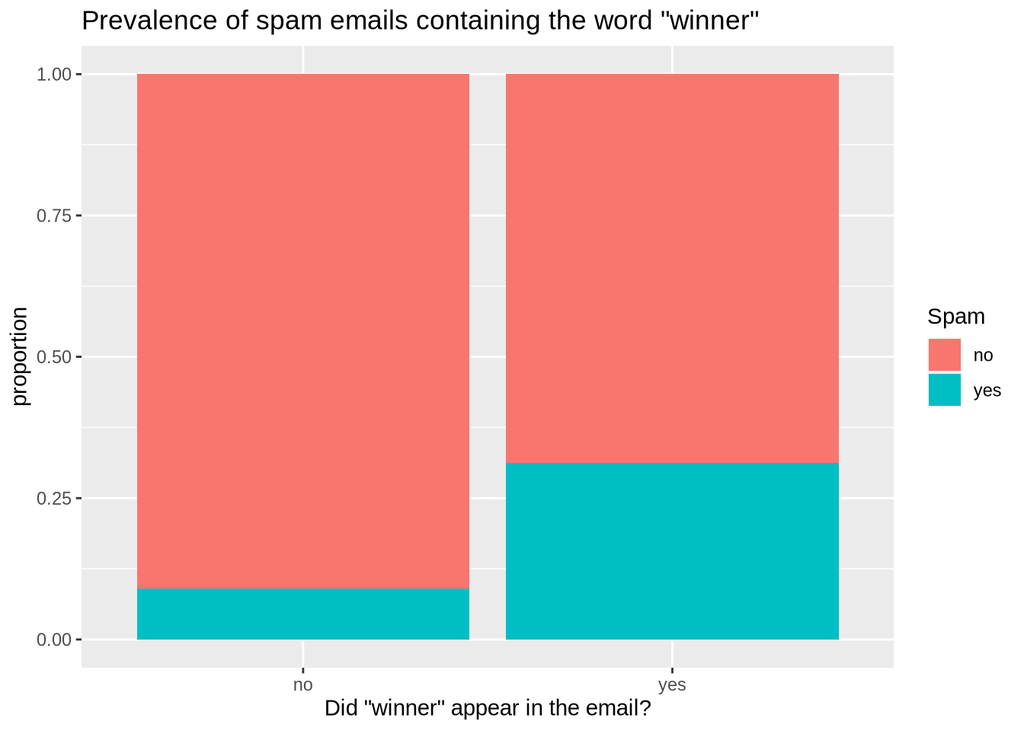

```r
ggplot(data=email,
       mapping=aes(x = winner,
                   fill = Spam ))+
  geom_bar(position="fill") +
  labs(
      title = 'Prevalence of spam emails containing the word "winner"',
      x =  'Did "winner" appear in the email?',
      y = "proportion")
```

### Exercise 4

**Exercise 4.** Write code to create a contingency table of the frequencies for `Spam` and `number.` Be sure to show your code and also the output (without messages or warnings). Then write a couple of sentences describing how the two variables are related. Be sure to mention what %’s of spam we should see if the variables are unrelated as well as how the data is deviating from these expectations.

The code to complete this question is provided in the lab. (Remember you need to adapt the code to the current exercise!)

```r
email %>%
   tabyl(format, Spam) %>%
   adorn_totals(where="row") %>%
   adorn_percentages(denominator="row") %>%
   adorn_pct_formatting(digits=2) %>%
   adorn_ns() %>%
   adorn_title()
```

```
##                   Spam
##  format             no          yes
##       0 82.51%   (986) 17.49% (209)
##       1 94.20% (2,568)  5.80% (158)
##   Total 90.64% (3,554)  9.36% (367)
```

**Hint:** you should replace `format` with a different variable.

### Exercise 5

**Exercise 5.** Create a mosaic plot for your table from exercise 4. Be sure to show your code and output (without messages or warnings). Also write a sentence on what you learn from the plot.

You can adapt the code provided for the `mosaicplot()` function earlier in the lab:

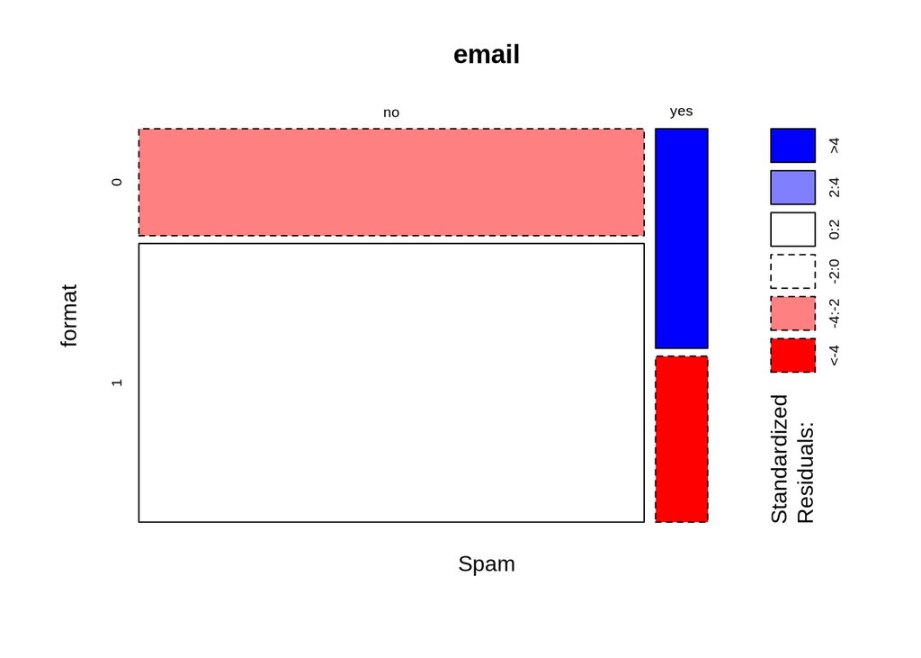

```r
mosaicplot(Spam ~ format, data=email, shade=TRUE)
```

**Hint:** you should switch out `format` for a different variable.